# P1: Describing a Perceptual Phenomenon

Tobias Weise

March 30, 2016

In the following document, I discuss an analysis of a perceptual phenomenon – the [*Stroop effect*](https://en.wikipedia.org/wiki/Stroop_effect). It shows that people take longer and are more likely to make errors when identifying the ink color of words when those words are adjectives describing different colors.

# Describing the experiment

For the experiment, participants are presented with a list of words displayed in different ink colors. They are asked to say the color of the ink the word is written in. The individuals are presented with two kinds of words-ink combinations. First, *congruent words* are those where the color of ink matches the displayed color adjective. Second, *incongruent words* are those where the color of ink does not match the displayed color word (e.g. `blue` printed in red). Each participant gets the same number of congruent and incongruent words. Time for saying the ink color is recorded for both congruent and incongruent words.

The *dependent variable* of this experiment is the recorded time to say the color of the ink. *The independent variables* are the kinds of words (congruent or incongruent) that the test subjects are evaluating.

# Developing a hypothesis and a hypothesis test

Let’s assume that the time it takes to say the color of ink is dependent on the kind of words that test subjects evaluate. Because we know about the Stroop effect, we assume that it will take individuals longer to evaluate incongruent words than congruent words. With $\mu_{c}$ representing the mean time for evaluating congruent words and $\mu_{i}$ the mean time for representing incongruent words, I test the following alternative hypothesis:

$$H_{A}: \mu_{i} > \mu_{c}$$

To *test the hyptheses*, I run a *dependent t-test for paired samples.* The test is appropriate because it fits the repeated treatment experimental design: individuals are treated with both congruent and incongruent words. I use a *one-tailed* version of the test because I assume that $\mu_{i} > \mu_{c}$. My expectations about the effects of the treatment are directed.

# Descriptive Statistics

Next, here are a number of descriptive statistics of the test results:

- $n = 24$, i.e. 24 people took the test.
- $\bar{x_{c}} = 14.05$ and $\bar{x_{i}} = 22.02$, i.e. on average, it took the individuals 14.05 seconds to read the congruent words and 22.02 seconds to read the incongruent words.
- $median_{c} = 14.36$ and $median_{i} = 21.02$, i.e. the individuals in the middle of the distribution took 14.36 seconds for reading congruent words and 21.02 seconds for reading incongruent words.
- $\sigma_{c} = 3.56$ and $\sigma_{i} = 4.8$, i.e. the standard deviation, and thus the spread of the data, is larger for the incongruent words.

The same becomes visible in the boxplots chart below. Again, the boxplots show the larger median for the incongruent words. Further, the boxplots well illustrate that the spread of the response times is larger for the incongruent words (larger box size, presence of outliers).

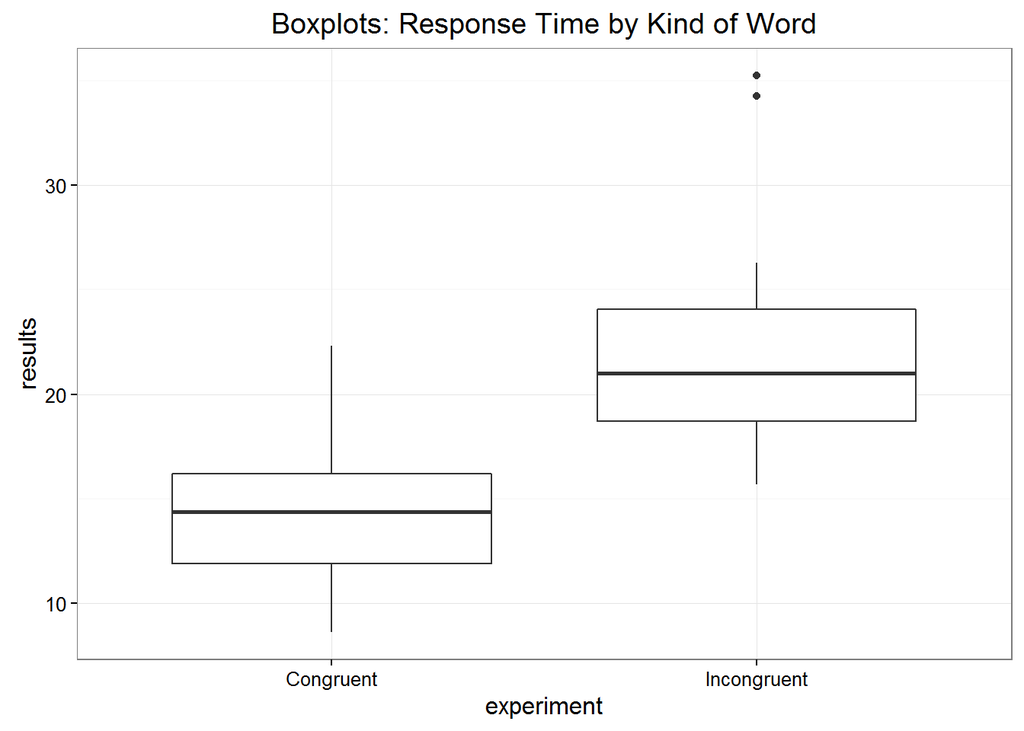

# Hypothesis test and interpretation of results

Next, I present the results of the one-tailed dependent t-test for paired samples:

```
##
##  Paired t-test
##
## data:  data$Congruent and data$Incongruent
## t = -8.0207, df = 23, p-value = 2.052e-08
## alternative hypothesis: true difference in means is less than 0
## 95 percent confidence interval:
##       -Inf -6.262868
## sample estimates:
## mean of the differences
##               -7.964792
```

Here are the results in more detail:

- the point estimate of difference is -7.9647917. Thus on average, people need about 8 seconds more to read incongruent words.
- the standard deviation of the difference is 4.8648269
- the standard error of the difference is 0.9930286
- the t-statistic is -8.0207069
- the critical values for an alpha level of 0.05 for a one-tailed test is -1.7139
- the calculated t-value is well below -1.7139. Thus we reject the null-hypothesis $H_{0}$
- the difference between the groups is statistically significant at a p-value of < 0.0001

Again, I reject $H_{0}$. Thus, the data show that the Stroop effect is indeed at work in the sample of individuals. Not only does the descriptive statistic show that reading time for incongruent pairs is longer. The t-test results also show that this difference is significantly different with a chance of being caused by change of < 0.001.

# Digging deeper

Is the data normally distributed? This is a core assumption of the t-test. So, one should test if the underlying data is normally distributed. Here, I present the results of a Shapiro-Wilk-Test for normality.

First, for the group of congruent words, we find that the data appears to be normally distributed:

```
##
##  Shapiro-Wilk normality test
##
## data:  data$Congruent
## W = 0.97092, p-value = 0.6898
```

However, for the group of incongruent words, we find that they are not:

```
##
##  Shapiro-Wilk normality test
##
## data:  data$Incongruent
## W = 0.85395, p-value = 0.00259
```

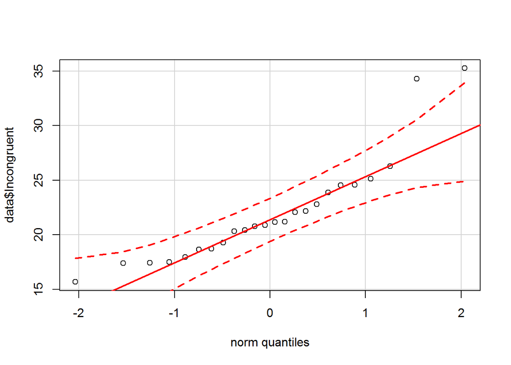

As the *q-q-plot* suggests, there are two outliers in the data that might influence results because they are not covered by the normal distribution. Those are cases `15` and `20` that have extremely high response times.

Thus, a first strategy could be to exclude those cases and re-run the t-test. Here are the results, which still confirm the findings of the first t-test. Thus, the two outlier cases do not strongly bias the data and the results of the original t-test.

```
##
##  Paired t-test
##
## data:  new_data$Congruent and new_data$Incongruent
## t = -9.5411, df = 21, p-value = 2.191e-09
## alternative hypothesis: true difference in means is less than 0
## 95 percent confidence interval:
##       -Inf -5.669776
## sample estimates:
## mean of the differences
##               -6.917318
```